# Breathing analysis

2022-05-05

# Breathing rate (cycles per minute)

## Per ACT (all conditions)

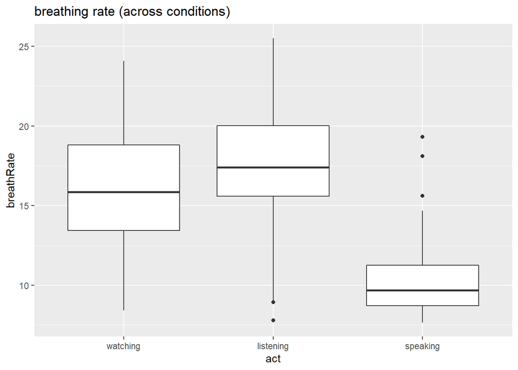

```
## Linear mixed model fit by REML ['lmerMod']
## Formula: breathRate ~ act + (1 | Speaker)
##    Data: br %>% filter(Role == "Participant")
##
## REML criterion at convergence: 684
##
## Scaled residuals:
##      Min       1Q   Median       3Q      Max
## -2.46401 -0.60159 -0.01842  0.55095  2.75462
##
## Random effects:
##  Groups   Name        Variance Std.Dev.
##  Speaker  (Intercept) 6.459    2.541
##  Residual             5.583    2.363
## Number of obs: 141, groups:  Speaker, 22
##
## Fixed effects:
##              Estimate Std. Error t value
## (Intercept)   15.8040     0.6299  25.092
## actlistening   1.1277     0.7992   1.411
## actspeaking   -5.4584     0.4285 -12.739
##
## Correlation of Fixed Effects:
##             (Intr) actlst
## actlistenng -0.215
## actspeaking -0.376  0.250
```

## But dividing per condition, a similar pattern emerges every time, but with a difference between sitting and biking

### During SITTING

**No difference between watching and listening**

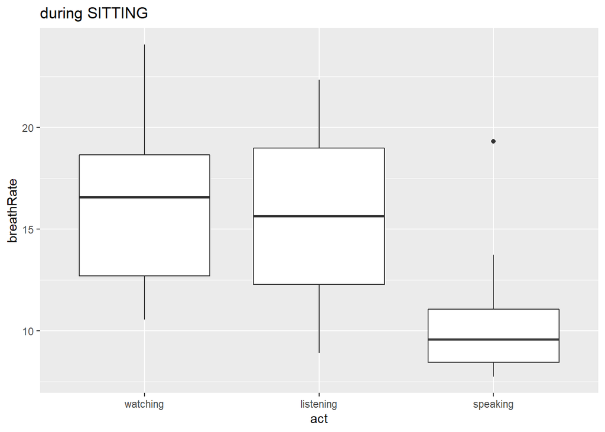

```
## Linear mixed model fit by REML ['lmerMod']
## Formula: breathRate ~ act + (1 | Speaker)
##    Data: br %>% filter(Role == "Participant") %>% filter(Condition ==
##     "Sitting")
##
## REML criterion at convergence: 207.3
##
## Scaled residuals:
##      Min       1Q   Median       3Q      Max
## -1.15188 -0.71983  0.04427  0.50676  2.09705
##
## Random effects:
##  Groups   Name        Variance Std.Dev.
##  Speaker  (Intercept) 6.748    2.598
##  Residual             6.468    2.543
## Number of obs: 41, groups:  Speaker, 22
##
## Fixed effects:
##              Estimate Std. Error t value
## (Intercept)   16.1456     0.8205  19.678
## actlistening  -1.2378     2.4400  -0.507
## actspeaking   -5.8150     0.8303  -7.003
##
## Correlation of Fixed Effects:
##             (Intr) actlst
## actlistenng -0.238
## actspeaking -0.522  0.124
```

### During LIGHT BIKING

**Difference between watching and listening! Though not in the regression**

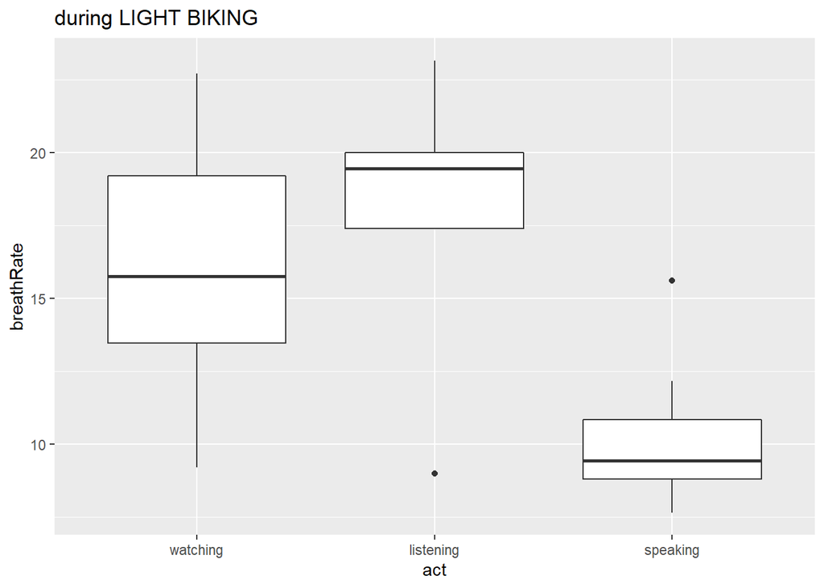

```
## Linear mixed model fit by REML ['lmerMod']
## Formula: breathRate ~ act + (1 | Speaker)
##    Data: br %>% filter(Role == "Participant") %>% filter(Condition ==
##     "Light")
##
## REML criterion at convergence: 202.2
##
## Scaled residuals:
##     Min      1Q  Median      3Q     Max
## -1.8140 -0.4630  0.0611  0.4506  1.8750
##
## Random effects:
##  Groups   Name        Variance Std.Dev.
##  Speaker  (Intercept) 5.104    2.259
##  Residual             7.217    2.686
## Number of obs: 40, groups:  Speaker, 22
##
## Fixed effects:
##              Estimate Std. Error t value
## (Intercept)   15.9030     0.8144  19.528
## actlistening   1.4154     1.5492   0.914
## actspeaking   -5.7924     0.9475  -6.113
##
## Correlation of Fixed Effects:
##             (Intr) actlst
## actlistenng -0.345
## actspeaking -0.557  0.192
```

### During HEAVY BIKING

**Also difference between watching and listening in graph but not in regression**

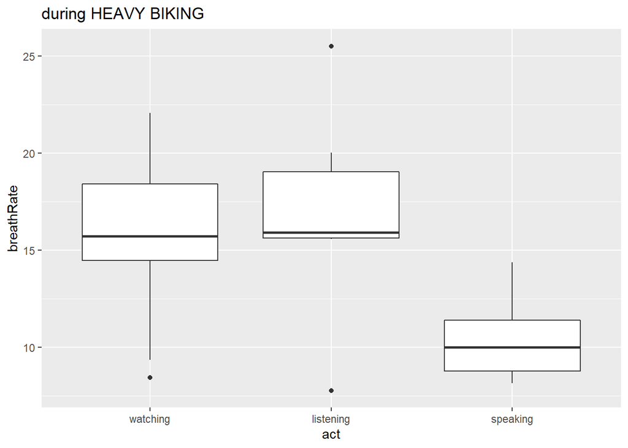

```
## Linear mixed model fit by REML ['lmerMod']
## Formula: breathRate ~ act + (1 | Speaker)
##    Data: br %>% filter(Role == "Participant") %>% filter(Condition ==
##     "Heavy")
##
## REML criterion at convergence: 215.7
##
## Scaled residuals:
##     Min      1Q  Median      3Q     Max
## -2.0104 -0.4073 -0.1194  0.6661  1.8826
##
## Random effects:
##  Groups   Name        Variance Std.Dev.
##  Speaker  (Intercept) 3.388    1.841
##  Residual             9.216    3.036
## Number of obs: 42, groups:  Speaker, 22
##
## Fixed effects:
##              Estimate Std. Error t value
## (Intercept)   15.7409     0.7919  19.877
## actlistening   1.1343     1.5540   0.730
## actspeaking   -5.5189     1.0325  -5.345
##
## Correlation of Fixed Effects:
##             (Intr) actlst
## actlistenng -0.416
## actspeaking -0.561  0.233
```

## Per Condition (all acts)

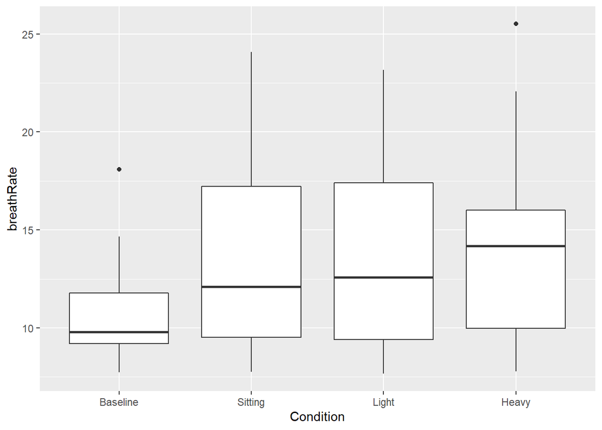

```
## Linear mixed model fit by REML ['lmerMod']
## Formula: breathRate ~ Condition + (1 | Speaker)
##    Data: br %>% filter(Role == "Participant")
##
## REML criterion at convergence: 788.5
##
## Scaled residuals:
##     Min      1Q  Median      3Q     Max
## -2.1501 -0.7096 -0.1328  0.6602  2.3883
##
## Random effects:
##  Groups   Name        Variance Std.Dev.
##  Speaker  (Intercept)  6.634   2.576
##  Residual             13.437   3.666
## Number of obs: 141, groups:  Speaker, 22
##
## Fixed effects:
##                   Estimate Std. Error t value
## (Intercept)        13.2031     0.7954  16.600
## ConditionBaseline  -2.3001     1.0433  -2.205
## ConditionHeavy      0.5223     0.8070   0.647
## ConditionLight      0.3717     0.8153   0.456
##
## Correlation of Fixed Effects:
##             (Intr) CndtnB CndtnH
## ConditnBsln -0.394
## ConditinHvy -0.514  0.386
## ConditnLght -0.506  0.385  0.498
```

## Per condition during WATCHING

### I guess we didn’t replicate Paccalin & Jeannerod! (Though this could be a methodological problem: shorter recordings of “only watching”)

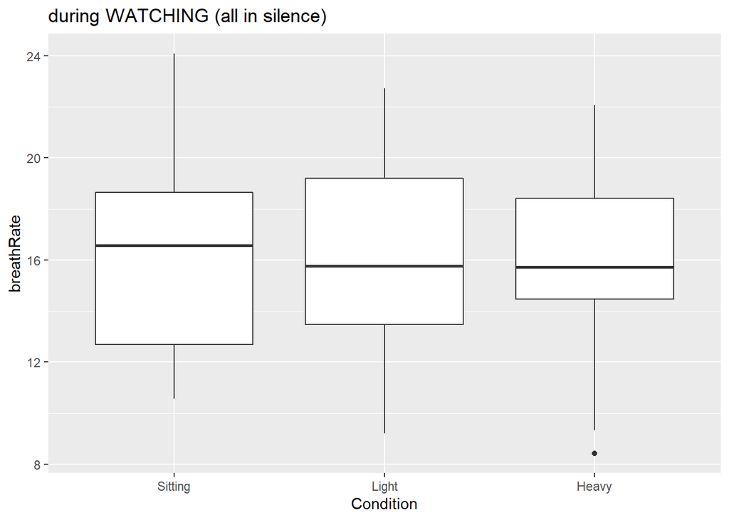

```
## Linear mixed model fit by REML ['lmerMod']
## Formula: breathRate ~ Condition + (1 | Speaker)
##    Data: br %>% filter(Role == "Participant") %>% filter(act == "watching")
##
## REML criterion at convergence: 282.1
##
## Scaled residuals:
##      Min       1Q   Median       3Q      Max
## -2.07664 -0.41767  0.03039  0.42510  2.25660
##
## Random effects:
##  Groups   Name        Variance Std.Dev.
##  Speaker  (Intercept) 11.456   3.385
##  Residual              4.281   2.069
## Number of obs: 57, groups:  Speaker, 21
##
## Fixed effects:
##                Estimate Std. Error t value
## (Intercept)    16.17562    0.88687  18.239
## ConditionHeavy -0.65155    0.67941  -0.959
## ConditionLight -0.09124    0.68439  -0.133
##
## Correlation of Fixed Effects:
##             (Intr) CndtnH
## ConditinHvy -0.402
## ConditnLght -0.371  0.484
```

## per CONDITION during LISTENING

### there there seems to be a clear difference, but the regression says otherwise…

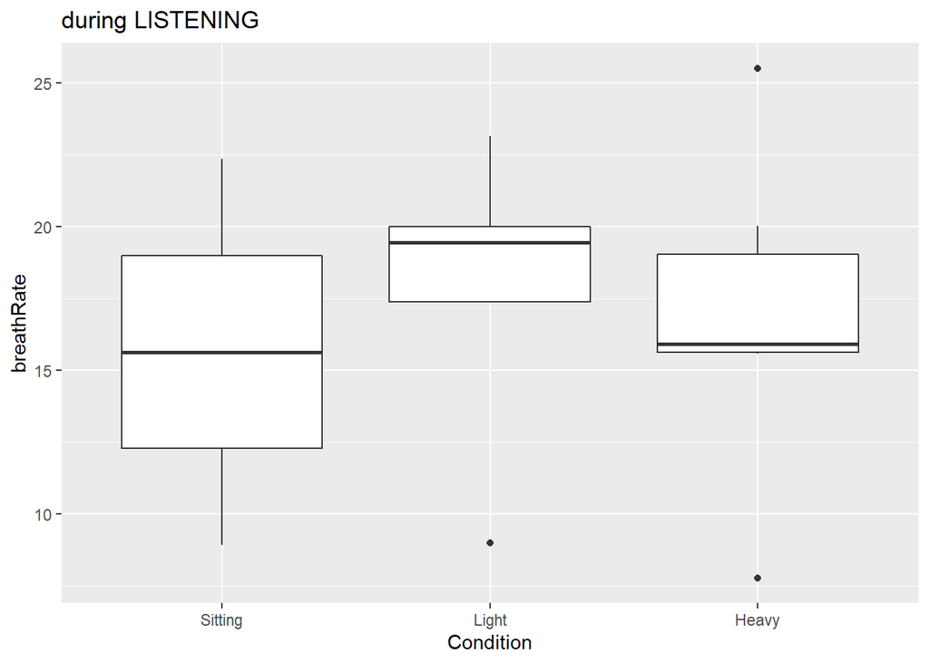

```
## Linear mixed model fit by REML ['lmerMod']
## Formula: breathRate ~ Condition + (1 | Speaker)
##    Data: br %>% filter(Role == "Participant") %>% filter(act == "listening")
##
## REML criterion at convergence: 59.7
##
## Scaled residuals:
##      Min       1Q   Median       3Q      Max
## -0.53167 -0.30176 -0.03183  0.13190  0.92501
##
## Random effects:
##  Groups   Name        Variance Std.Dev.
##  Speaker  (Intercept) 26.9809  5.1943
##  Residual              0.8887  0.9427
## Number of obs: 13, groups:  Speaker, 9
##
## Fixed effects:
##                Estimate Std. Error t value
## (Intercept)     14.7024     1.9382   7.586
## ConditionHeavy   2.0015     1.0733   1.865
## ConditionLight   0.8436     0.9075   0.929
##
## Correlation of Fixed Effects:
##             (Intr) CndtnH
## ConditinHvy -0.402
## ConditnLght -0.354  0.608
```

## per CONDITION during SPEAKING

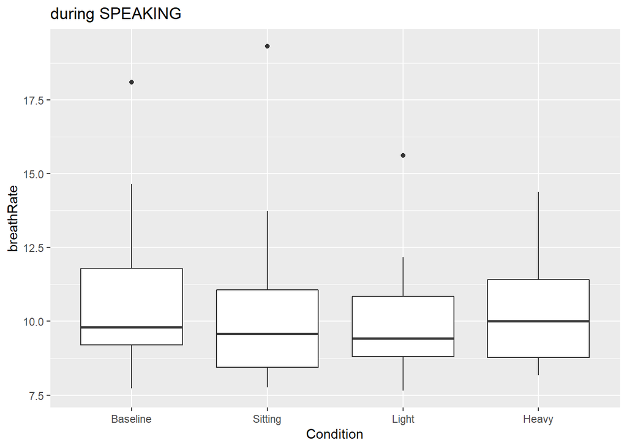

```
## Linear mixed model fit by REML ['lmerMod']
## Formula: breathRate ~ Condition + (1 | Speaker)
##    Data: br %>% filter(Role == "Participant") %>% filter(act == "speaking")
##
## REML criterion at convergence: 294.2
##
## Scaled residuals:
##     Min      1Q  Median      3Q     Max
## -1.9959 -0.4198 -0.0927  0.2242  4.6984
##
## Random effects:
##  Groups   Name        Variance Std.Dev.
##  Speaker  (Intercept) 2.798    1.673
##  Residual             2.526    1.589
## Number of obs: 71, groups:  Speaker, 21
##
## Fixed effects:
##                   Estimate Std. Error t value
## (Intercept)        10.2158     0.5126  19.931
## ConditionBaseline   0.3819     0.5199   0.735
## ConditionHeavy     -0.3033     0.5483  -0.553
## ConditionLight     -0.3050     0.5304  -0.575
##
## Correlation of Fixed Effects:
##             (Intr) CndtnB CndtnH
## ConditnBsln -0.474
## ConditinHvy -0.465  0.438
## ConditnLght -0.465  0.455  0.438
```

### but we can also exclude those 2 high values (z scores = 1.53 and 1.79), and then we find a slight effect between conditions, and a clearer effect in baseline vs conditions

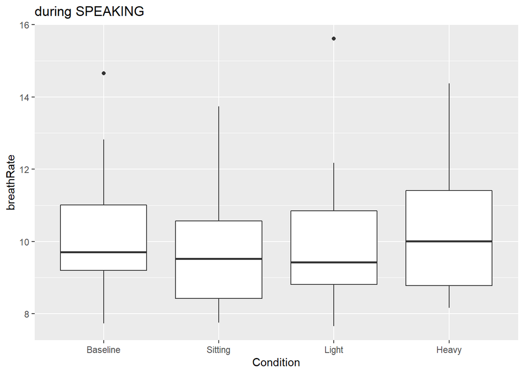

```
## Linear mixed model fit by REML ['lmerMod']
## Formula: breathRate ~ Condition + (1 | Speaker)
##    Data:
## br %>% filter(Role == "Participant") %>% filter(act == "speaking") %>%
##     filter(breathRate < 17.5)
##
## REML criterion at convergence: 223.2
##
## Scaled residuals:
##     Min      1Q  Median      3Q     Max
## -1.4978 -0.5499 -0.0616  0.5499  2.7276
##
## Random effects:
##  Groups   Name        Variance Std.Dev.
##  Speaker  (Intercept) 2.6314   1.6222
##  Residual             0.6954   0.8339
## Number of obs: 69, groups:  Speaker, 21
##
## Fixed effects:
##                   Estimate Std. Error t value
## (Intercept)        9.65537    0.40507  23.836
## ConditionBaseline  0.69532    0.28395   2.449
## ConditionHeavy     0.28477    0.29615   0.962
## ConditionLight     0.07975    0.28129   0.284
##
## Correlation of Fixed Effects:
##             (Intr) CndtnB CndtnH
## ConditnBsln -0.327
## ConditinHvy -0.331  0.441
## ConditnLght -0.321  0.454  0.447
```

## Interaction Condition * Act

**a bit hard to interpret**

```
## fixed-effect model matrix is rank deficient so dropping 2 columns / coefficients
```

```
## Linear mixed model fit by REML ['lmerMod']
## Formula: breathRate ~ act * Condition + (1 | Speaker)
##    Data: br %>% filter(Role == "Participant")
##
## REML criterion at convergence: 669.6
##
## Scaled residuals:
##     Min      1Q  Median      3Q     Max
## -2.4835 -0.5362 -0.0843  0.5448  2.7587
##
## Random effects:
##  Groups   Name        Variance Std.Dev.
##  Speaker  (Intercept) 6.409    2.532
##  Residual             5.807    2.410
## Number of obs: 141, groups:  Speaker, 22
##
## Fixed effects:
##                             Estimate Std. Error t value
## (Intercept)                 16.05790    0.77822  20.634
## actlistening                -0.88361    1.96922  -0.449
## actspeaking                 -5.75392    0.77780  -7.398
## ConditionBaseline            0.56807    0.78651   0.722
## ConditionHeavy              -0.49625    0.77799  -0.638
## ConditionLight              -0.20904    0.79417  -0.263
## actlistening:ConditionHeavy  2.46550    2.28583   1.079
## actspeaking:ConditionHeavy   0.31367    1.12365   0.279
## actlistening:ConditionLight  2.31694    2.23921   1.035
## actspeaking:ConditionLight   0.02637    1.12735   0.023
##
## Correlation of Fixed Effects:
##             (Intr) actlst actspk CndtnB CndtnH CndtnL actl:CH acts:CH actl:CL
## actlistenng -0.224
## actspeaking -0.515  0.183
## ConditnBsln  0.004 -0.001 -0.479
## ConditinHvy -0.516  0.227  0.510 -0.006
## ConditnLght -0.495  0.197  0.494  0.000  0.494
## actlstnn:CH  0.190 -0.854 -0.156  0.005 -0.367 -0.168
## actspkng:CH  0.355 -0.135 -0.688  0.330 -0.683 -0.343  0.217
## actlstnn:CL  0.188 -0.819 -0.166  0.002 -0.189 -0.355  0.702   0.118
## actspkng:CL  0.347 -0.141 -0.678  0.326 -0.348 -0.705  0.120   0.471   0.242
## fit warnings:
## fixed-effect model matrix is rank deficient so dropping 2 columns / coefficients
```

# Breath cycle duration

## Confederate

**In confederate, expected change in breath cycle duration per condition (but in the regression there was no light vs heavy difference, although (the tendency to) the expeceted pattern still holds**

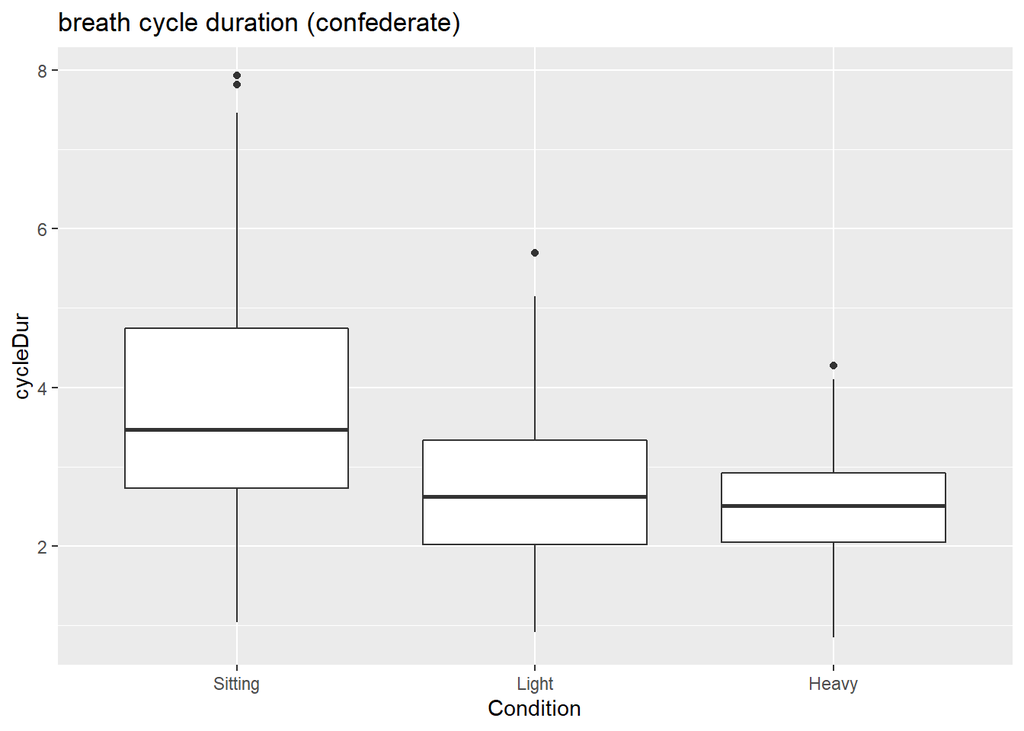

```
##
## Call:
## lm(formula = cycleDur ~ Condition, data = br %>% filter(Role ==
##     "Confederate"))
##
## Residuals:
##     Min      1Q  Median      3Q     Max
## -2.7906 -0.6674 -0.0674  0.5886  4.1003
##
## Coefficients:
##                Estimate Std. Error t value Pr(>|t|)
## (Intercept)     3.83411    0.09353  40.995   <2e-16 ***
## ConditionHeavy -1.35087    0.12499 -10.808   <2e-16 ***
## ConditionLight -1.17603    0.12135  -9.692   <2e-16 ***
## ---
## Signif. codes:  0 '***' 0.001 '**' 0.01 '*' 0.05 '.' 0.1 ' ' 1
##
## Residual standard error: 1.091 on 505 degrees of freedom
## Multiple R-squared:  0.2106, Adjusted R-squared:  0.2075
## F-statistic: 67.36 on 2 and 505 DF,  p-value: < 2.2e-16
```

```
##
## Call:
## lm(formula = cycleDur ~ Condition, data = br %>% filter(Role ==
##     "Confederate"))
##
## Residuals:
##     Min      1Q  Median      3Q     Max
## -2.7906 -0.6674 -0.0674  0.5886  4.1003
##
## Coefficients:
##                  Estimate Std. Error t value Pr(>|t|)
## (Intercept)       2.65808    0.07732  34.379   <2e-16 ***
## ConditionSitting  1.17603    0.12135   9.692   <2e-16 ***
## ConditionHeavy   -0.17484    0.11338  -1.542    0.124
## ---
## Signif. codes:  0 '***' 0.001 '**' 0.01 '*' 0.05 '.' 0.1 ' ' 1
##
## Residual standard error: 1.091 on 505 degrees of freedom
## Multiple R-squared:  0.2106, Adjusted R-squared:  0.2075
## F-statistic: 67.36 on 2 and 505 DF,  p-value: < 2.2e-16
```

## Per condition, during WATCHING

**no effect! Weird “outliers”?**

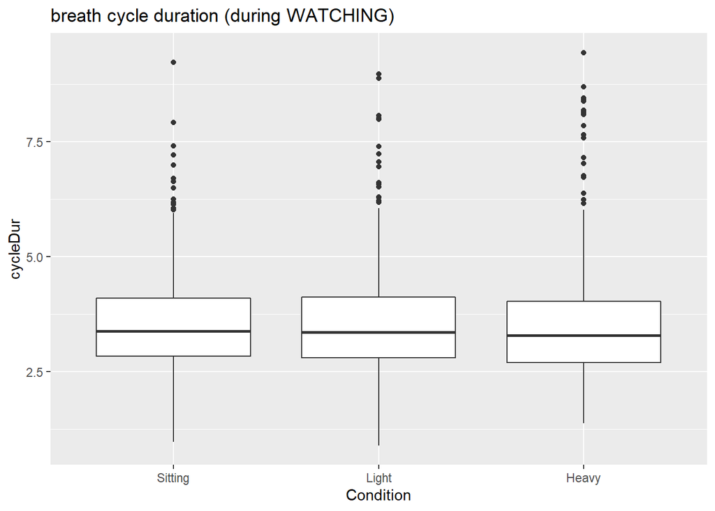

```
## Linear mixed model fit by REML ['lmerMod']
## Formula: cycleDur ~ Condition + (1 | Speaker)
##    Data: br %>% filter(Role == "Participant") %>% filter(act == "watching")
##
## REML criterion at convergence: 2405.6
##
## Scaled residuals:
##     Min      1Q  Median      3Q     Max
## -3.0850 -0.4693 -0.1419  0.3191  4.8946
##
## Random effects:
##  Groups   Name        Variance Std.Dev.
##  Speaker  (Intercept) 0.8784   0.9373
##  Residual             1.1374   1.0665
## Number of obs: 786, groups:  Speaker, 21
##
## Fixed effects:
##                Estimate Std. Error t value
## (Intercept)     3.83507    0.21653  17.712
## ConditionLight  0.07888    0.09547   0.826
## ConditionHeavy  0.06802    0.09558   0.712
##
## Correlation of Fixed Effects:
##             (Intr) CndtnL
## ConditnLght -0.218
## ConditinHvy -0.235  0.498
```

## Per condition, during LISTENING

**also no effect**

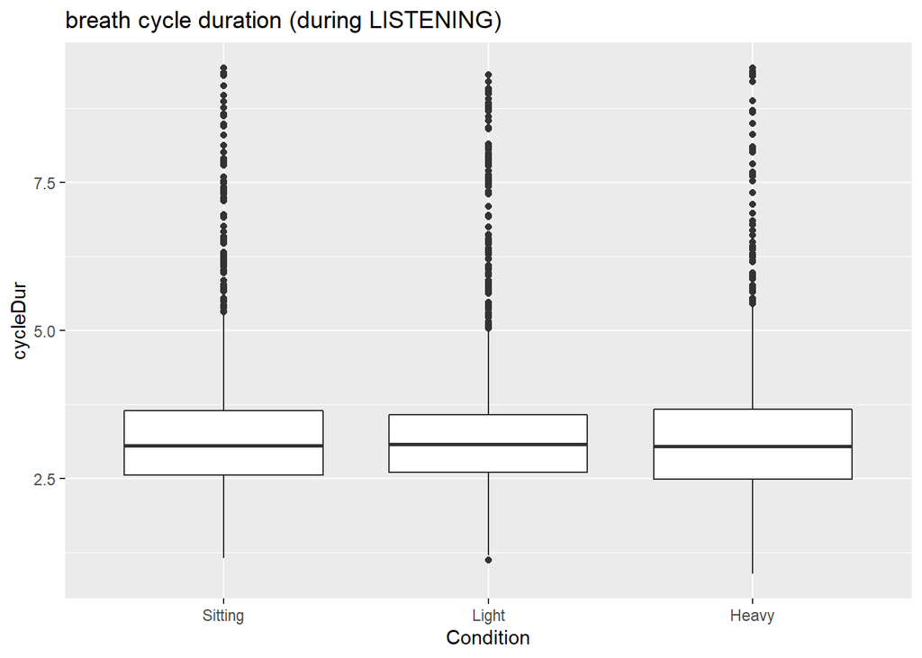

```
## Linear mixed model fit by REML ['lmerMod']
## Formula: cycleDur ~ Condition + (1 | Speaker)
##    Data: br %>% filter(Role == "Participant") %>% filter(act == "listening")
##
## REML criterion at convergence: 8842.8
##
## Scaled residuals:
##     Min      1Q  Median      3Q     Max
## -3.9020 -0.4204 -0.0854  0.2710  5.7099
##
## Random effects:
##  Groups   Name        Variance Std.Dev.
##  Speaker  (Intercept) 0.938    0.9685
##  Residual             1.043    1.0212
## Number of obs: 3032, groups:  Speaker, 22
##
## Fixed effects:
##                Estimate Std. Error t value
## (Intercept)     3.62580    0.20898  17.350
## ConditionLight  0.02953    0.04342   0.680
## ConditionHeavy -0.05803    0.04709  -1.232
##
## Correlation of Fixed Effects:
##             (Intr) CndtnL
## ConditnLght -0.100
## ConditinHvy -0.095  0.450
```

## Per condition, during SPEAKING

**also no effect**

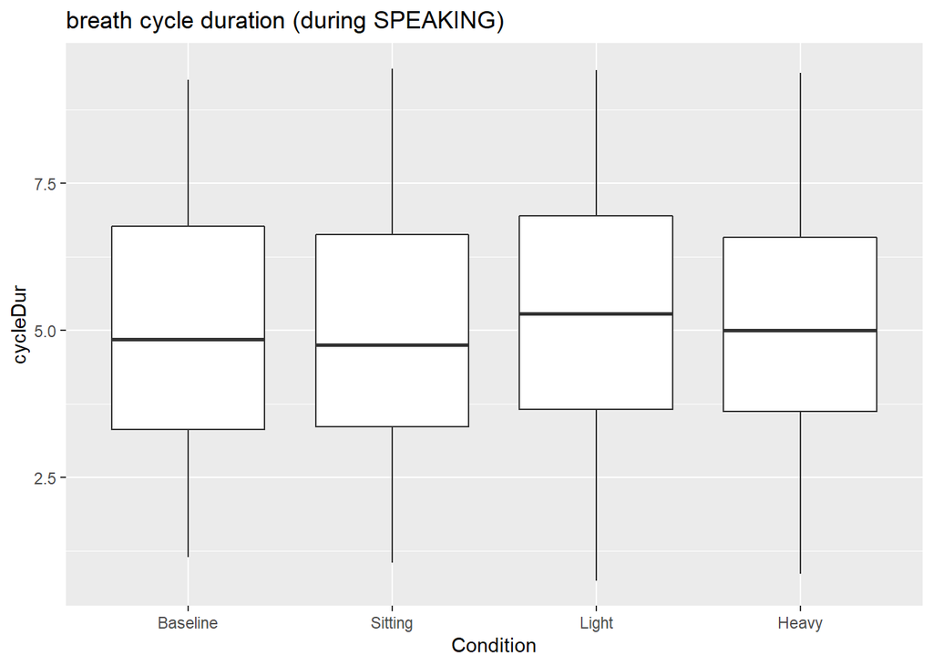

```
## Linear mixed model fit by REML ['lmerMod']
## Formula: cycleDur ~ Condition + (1 | Speaker)
##    Data: br %>% filter(Role == "Participant") %>% filter(act == "speaking")
##
## REML criterion at convergence: 7357.4
##
## Scaled residuals:
##      Min       1Q   Median       3Q      Max
## -2.46988 -0.75274 -0.06948  0.72833  2.67789
##
## Random effects:
##  Groups   Name        Variance Std.Dev.
##  Speaker  (Intercept) 0.4805   0.6932
##  Residual             3.7032   1.9244
## Number of obs: 1761, groups:  Speaker, 21
##
## Fixed effects:
##                   Estimate Std. Error t value
## (Intercept)         5.3279     0.1771  30.090
## ConditionLight      0.1755     0.1330   1.320
## ConditionBaseline  -0.1409     0.1274  -1.106
## ConditionHeavy      0.1204     0.1362   0.884
##
## Correlation of Fixed Effects:
##             (Intr) CndtnL CndtnB
## ConditnLght -0.337
## ConditnBsln -0.348  0.462
## ConditinHvy -0.333  0.466  0.436
```

## Per ACT, across conditions

**shorter cycles during listening: makes sense with higher breath rate during listening (see above).**

**clear effects on graph and regression**

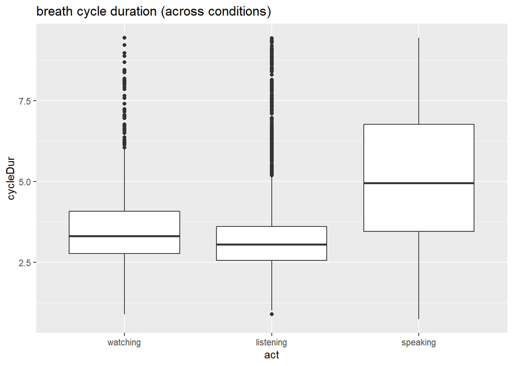

```
## Linear mixed model fit by REML ['lmerMod']
## Formula: cycleDur ~ act + (1 | Speaker)
##    Data: br %>% filter(Role == "Participant")
##
## REML criterion at convergence: 19930.9
##
## Scaled residuals:
##     Min      1Q  Median      3Q     Max
## -3.8782 -0.4713 -0.1210  0.3616  4.3309
##
## Random effects:
##  Groups   Name        Variance Std.Dev.
##  Speaker  (Intercept) 0.6104   0.7813
##  Residual             2.0473   1.4308
## Number of obs: 5579, groups:  Speaker, 22
##
## Fixed effects:
##              Estimate Std. Error t value
## (Intercept)   3.87651    0.17458  22.205
## actlistening -0.31297    0.05744  -5.448
## actspeaking   1.41444    0.06268  22.567
##
## Correlation of Fixed Effects:
##             (Intr) actlst
## actlistenng -0.263
## actspeaking -0.245  0.727
```

## Dividing by condition, cycle durations per act still hold the same pattern

## Per ACT, during SITTING

**watching vs listening: not so strong but present effect**

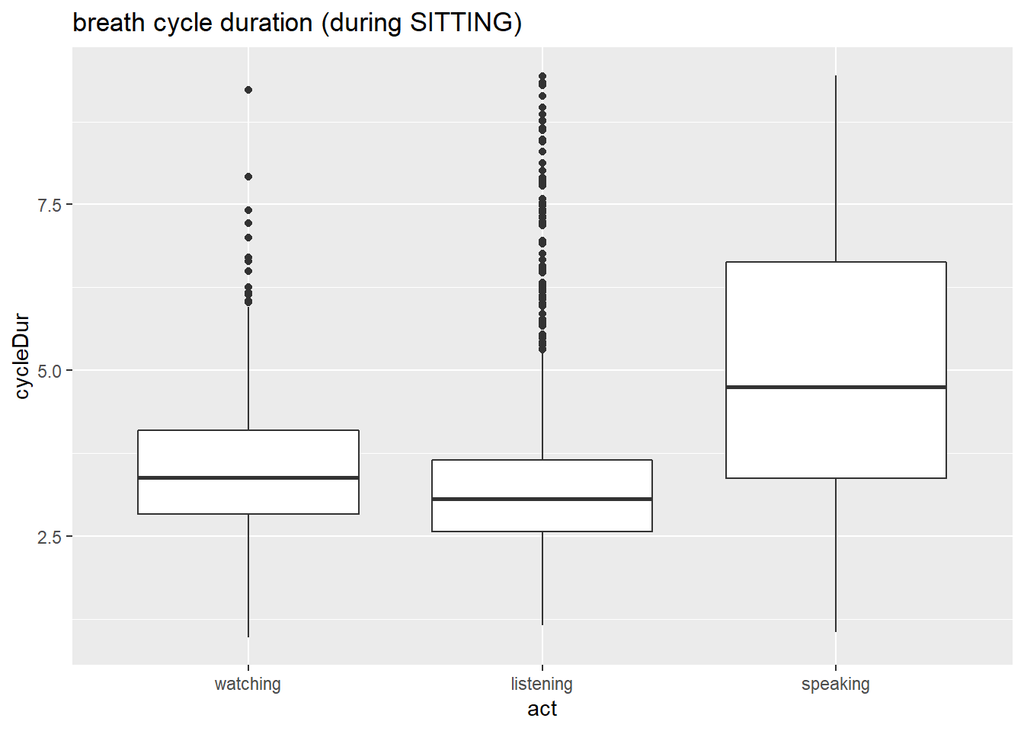

```
## Linear mixed model fit by REML ['lmerMod']
## Formula: cycleDur ~ act + (1 | Speaker)
##    Data: br %>% filter(Role == "Participant") %>% filter(Condition ==
##     "Sitting")
##
## REML criterion at convergence: 6512.7
##
## Scaled residuals:
##     Min      1Q  Median      3Q     Max
## -3.2414 -0.4633 -0.1345  0.3672  4.1611
##
## Random effects:
##  Groups   Name        Variance Std.Dev.
##  Speaker  (Intercept) 0.6956   0.834
##  Residual             1.7627   1.328
## Number of obs: 1889, groups:  Speaker, 22
##
## Fixed effects:
##              Estimate Std. Error t value
## (Intercept)   3.84945    0.19739  19.502
## actlistening -0.27132    0.09254  -2.932
## actspeaking   1.43855    0.10453  13.762
##
## Correlation of Fixed Effects:
##             (Intr) actlst
## actlistenng -0.387
## actspeaking -0.345  0.719
```

## Per ACT, during LIGHT BIKING

**slightly stronger effect in watching vs listening**

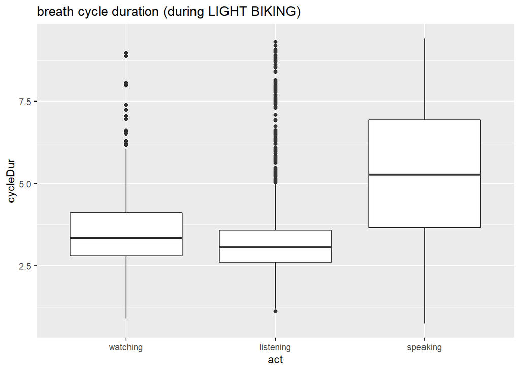

```
## Linear mixed model fit by REML ['lmerMod']
## Formula: cycleDur ~ act + (1 | Speaker)
##    Data: br %>% filter(Role == "Participant") %>% filter(Condition ==
##     "Light")
##
## REML criterion at convergence: 6130.7
##
## Scaled residuals:
##     Min      1Q  Median      3Q     Max
## -3.5235 -0.4245 -0.1104  0.2815  4.1790
##
## Random effects:
##  Groups   Name        Variance Std.Dev.
##  Speaker  (Intercept) 0.8101   0.9001
##  Residual             1.8535   1.3614
## Number of obs: 1751, groups:  Speaker, 22
##
## Fixed effects:
##              Estimate Std. Error t value
## (Intercept)   3.98006    0.21152  18.817
## actlistening -0.36209    0.09556  -3.789
## actspeaking   1.51843    0.11293  13.445
##
## Correlation of Fixed Effects:
##             (Intr) actlst
## actlistenng -0.370
## actspeaking -0.323  0.690
```

## Per ACT, during HEAVY BIKING

**same watching vs listening effect as in light biking**

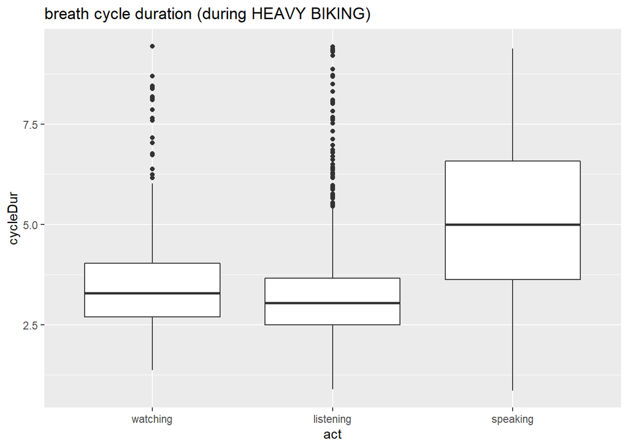

```
## Linear mixed model fit by REML ['lmerMod']
## Formula: cycleDur ~ act + (1 | Speaker)
##    Data: br %>% filter(Role == "Participant") %>% filter(Condition ==
##     "Heavy")
##
## REML criterion at convergence: 5236.7
##
## Scaled residuals:
##     Min      1Q  Median      3Q     Max
## -3.6936 -0.4788 -0.1380  0.3602  4.3423
##
## Random effects:
##  Groups   Name        Variance Std.Dev.
##  Speaker  (Intercept) 0.6154   0.7844
##  Residual             1.9345   1.3909
## Number of obs: 1477, groups:  Speaker, 22
##
## Fixed effects:
##              Estimate Std. Error t value
## (Intercept)   3.82481    0.18872  20.267
## actlistening -0.30686    0.09806  -3.129
## actspeaking   1.46746    0.11449  12.817
##
## Correlation of Fixed Effects:
##             (Intr) actlst
## actlistenng -0.392
## actspeaking -0.330  0.634
```

# Number of IPUs per breathing cycle, divded by condition

## Confederate

**When biking, the confederate seems to produce slightly fewer IPUs per breath cycle (makes sense! less breath when biking)**

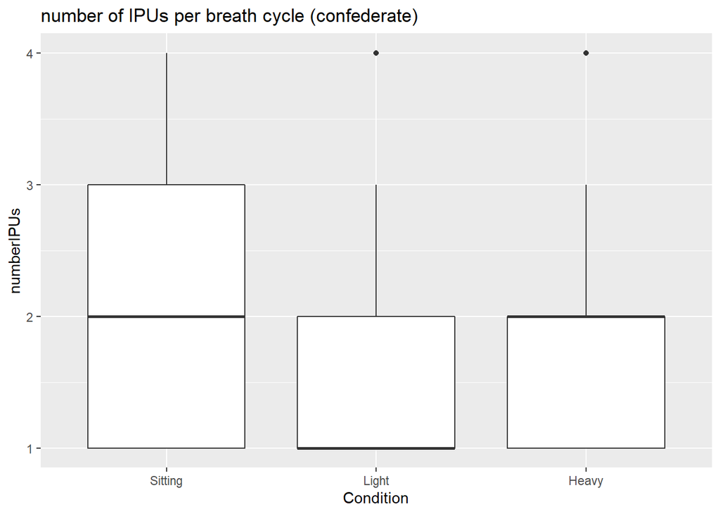

```
##
## Call:
## lm(formula = numberIPUs ~ Condition, data = br %>% filter(Role ==
##     "Confederate"))
##
## Residuals:
##     Min      1Q  Median      3Q     Max
## -0.8897 -0.6416  0.1103  0.4121  2.4121
##
## Coefficients:
##                Estimate Std. Error t value Pr(>|t|)
## (Intercept)     1.88971    0.06602  28.624  < 2e-16 ***
## ConditionHeavy -0.24809    0.08823  -2.812 0.005118 **
## ConditionLight -0.30177    0.08566  -3.523 0.000465 ***
## ---
## Signif. codes:  0 '***' 0.001 '**' 0.01 '*' 0.05 '.' 0.1 ' ' 1
##
## Residual standard error: 0.7699 on 505 degrees of freedom
## Multiple R-squared:  0.0257, Adjusted R-squared:  0.02185
## F-statistic: 6.662 on 2 and 505 DF,  p-value: 0.001394
```

## Participants

**Participants really don’t seem to change their IPUs per cycle across conditions**

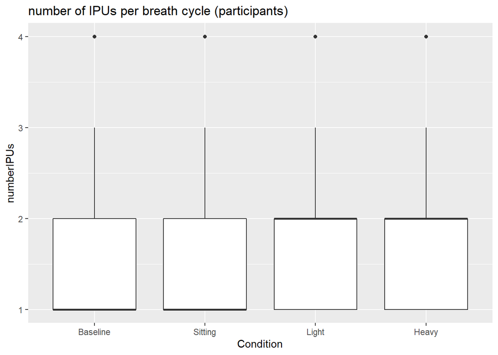

```
## Linear mixed model fit by REML ['lmerMod']
## Formula: numberIPUs ~ Condition + (1 | Speaker)
##    Data: br %>% filter(Role == "Participant")
##
## REML criterion at convergence: 4364.1
##
## Scaled residuals:
##     Min      1Q  Median      3Q     Max
## -1.2650 -0.8413 -0.3351  0.4930  3.1420
##
## Random effects:
##  Groups   Name        Variance Std.Dev.
##  Speaker  (Intercept) 0.05166  0.2273
##  Residual             0.67852  0.8237
## Number of obs: 1760, groups:  Speaker, 21
##
## Fixed effects:
##                   Estimate Std. Error t value
## (Intercept)        1.71262    0.06322  27.089
## ConditionBaseline  0.03449    0.05450   0.633
## ConditionHeavy     0.04554    0.05809   0.784
## ConditionLight     0.05799    0.05679   1.021
##
## Correlation of Fixed Effects:
##             (Intr) CndtnB CndtnH
## ConditnBsln -0.418
## ConditinHvy -0.398  0.439
## ConditnLght -0.405  0.463  0.466
```